# R Notebook

Question 1.

Load in the libraries you need, and look at the backpack data. Take note of variable names and dimensions.

```r
backpack %>%
  glimpse()
```

```
Rows: 100
Columns: 9
$ backpack_weight <int> 9, 8, 10, 6, 8, 5, 8, 4, 5, 2, 8, 21, 11, 11,…
$ body_weight     <int> 125, 195, 120, 155, 180, 240, 170, 185, 130, …
$ ratio           <dbl> 0.0720000, 0.0410256, 0.0833333, 0.0387097, 0…
$ back_problems   <int> 1, 0, 1, 0, 0, 0, 0, 1, 0, 0, 0, 0, 0, 1, 1, …
$ major           <fct> Bio, Philosophy, GRC, CSC, EE, History, CM, A…
$ year            <int> 3, 5, 4, 6, 2, 0, 3, 5, 4, 5, 3, 5, 4, 4, 3, …
$ sex             <fct> Female, Male, Female, Male, Female, Male, Mal…
$ status          <fct> U, U, U, G, U, G, U, U, U, U, U, U, U, U, U, …
$ units           <int> 13, 12, 14, 0, 14, 0, 15, 18, 14, 8, 15, 12, …
```

The table is 100 x 9 with thr following coloumn names: backpack_weight, body_weight ratio  
back_problems, major, year  
sex, status, units

Question 2.

What is the distribution of backpack weights that students are carrying? Choose an appropriate graph to show the distribution.

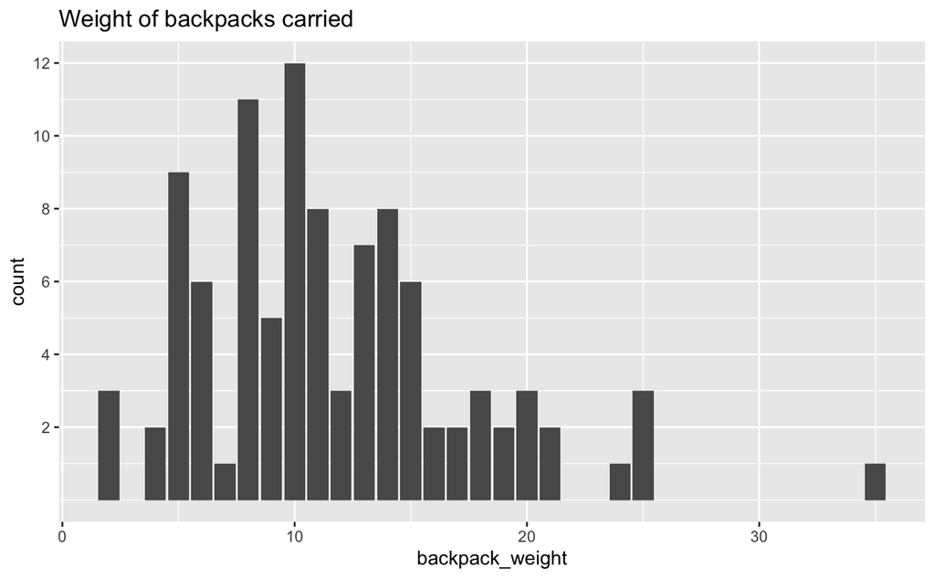

```r
backpack %>%
  ggplot() +
  aes(x = backpack_weight) +
  geom_bar() +
  scale_y_continuous(breaks = c(2,4,6,8,10,12,14)) +
  labs(
    title = "Weight of backpacks carried"
  )
```

Question 3.

Are there differences in backpack weight between sex?

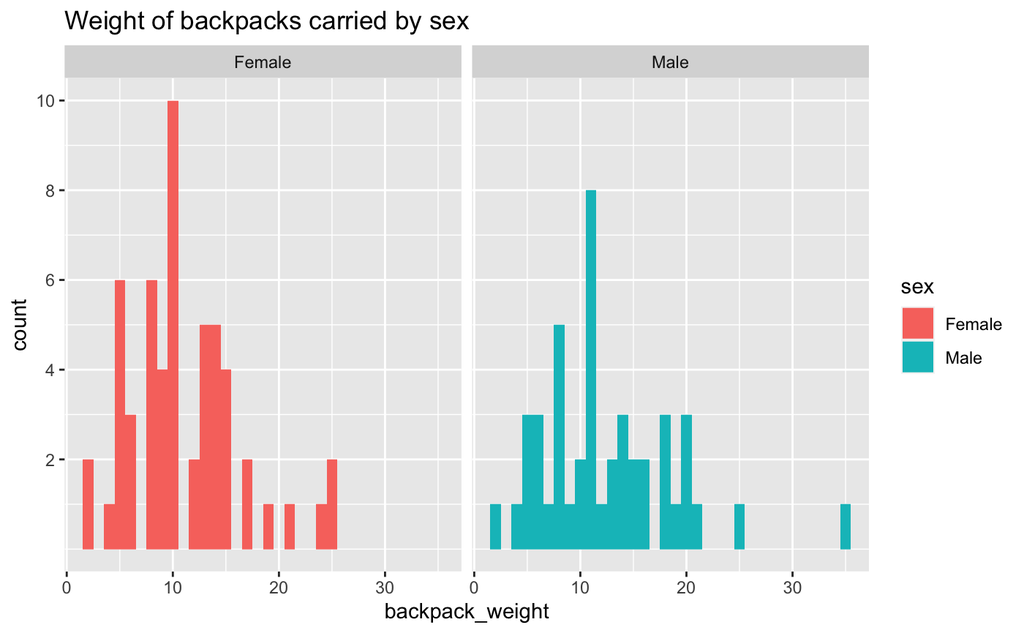

```r
backpack %>%
  ggplot() +
  aes(x = backpack_weight, fill = sex) +
  geom_histogram(position = "dodge", binwidth = 1) +
  scale_y_continuous(breaks = c(2,4,6,8,10,12,14)) +
  labs(
    title = "Weight of backpacks carried by sex"
  ) + facet_wrap(~ sex)
```

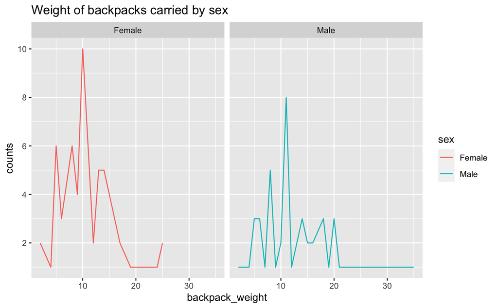

```r
count_data %>%
  ggplot() +
  aes(x = backpack_weight, y = counts, colour = sex) +
  geom_line() +
  scale_y_continuous(breaks = c(2,4,6,8,10,12,14)) +
  labs(
    title = "Weight of backpacks carried by sex"
  ) + facet_wrap(~sex)
```

```r
count_data <- backpack %>%
  group_by(backpack_weight, sex) %>%
  summarise(counts = n())
```

Summary: Females most common weight was 10kg while male was 11kg

Question 4.

What is the relationship between body weight and backpack weight?

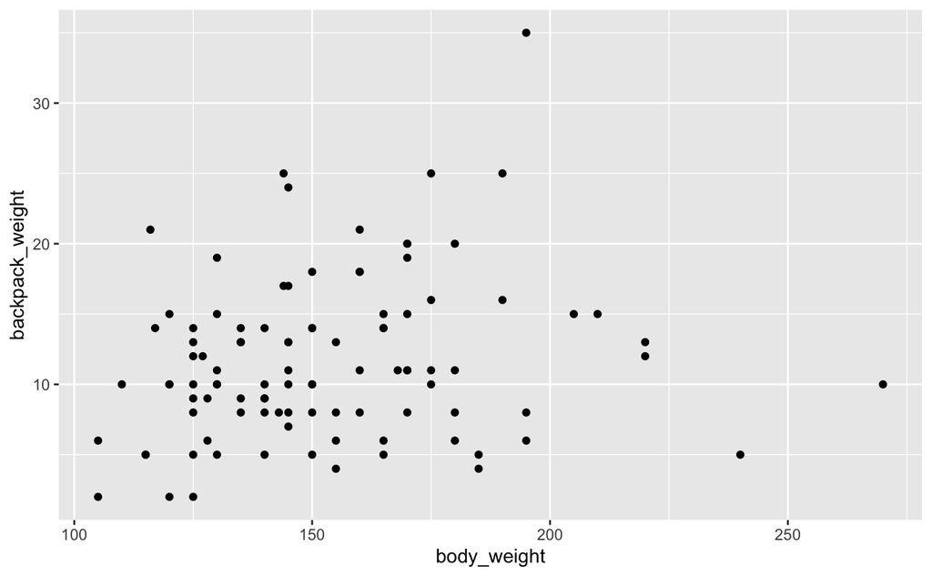

Summary: not really a relationship

Question 5.

Is this relationship different between men and women? Choose an appropriate plot and interpret your findings.

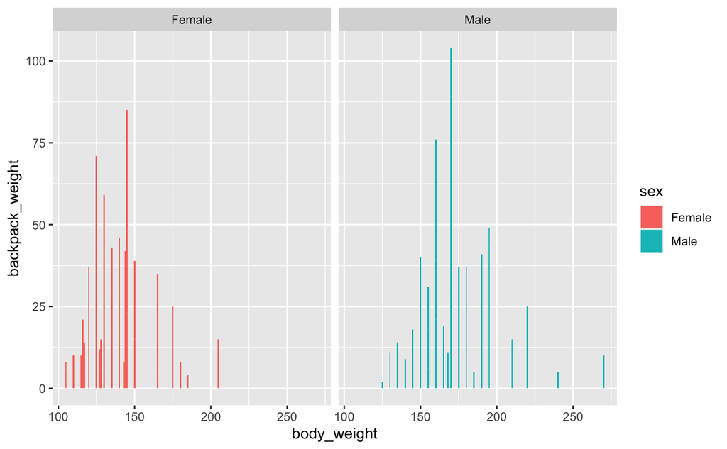

Question 6.

What proportion of students report back pain?

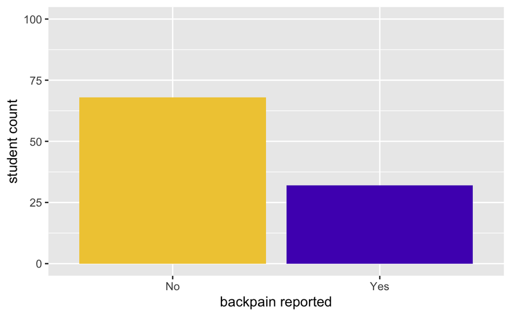

```r
proportions2 <- backpack %>%
  summarise(pp = mean(back_problems)) %>%
  pull(pp)

backpack <- backpack %>%
  mutate(backpain_labelled = recode(back_problems,
                       "0" = "No",
                       "1" = "Yes"))

ggplot(backpack) +
  aes(x = backpain_labelled, fill = backpain_labelled) +
  geom_bar() +
ylim(0,100) +
  labs(x = "backpain reported", y = "student count") +
    scale_fill_manual(values=c('#f0ca41', '#5022bd'))+
theme(legend.position = "none")
```

```r
NA
NA
```

Question 7.

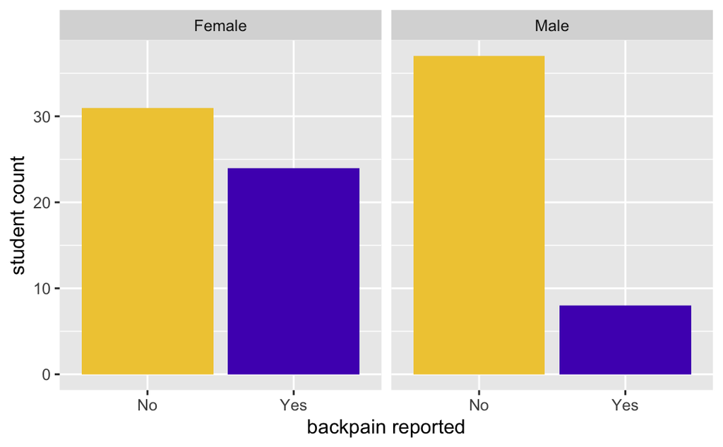

```r
ggplot(backpack) +
  aes(x = backpain_labelled, fill = backpain_labelled) +
  geom_bar() +
  labs(x = "backpain reported", y = "student count") +
  facet_wrap(~sex) +
      scale_fill_manual(values=c('#f0ca41', '#5022bd'))+
theme(legend.position = "none")
```

Is this proportion different between men and women?

Question 8.

Now you’ve investigated your data separately, create plots to describe the relationship between backpack weight, body weight, gender and reported backpain.

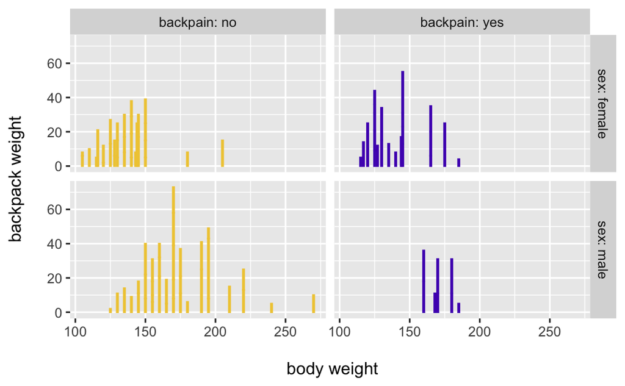

```r
pain_labels <- c("backpain: no", "backpain: yes")
names(pain_labels) <- c("No", "Yes")

sex_labels <- c("sex: female", "sex: male")
names(sex_labels) <- c("Female", "Male")


ggplot(backpack) +
  aes(x = body_weight, y = backpack_weight, color = backpain_labelled) +
  geom_col() +
  facet_grid(sex ~ backpain_labelled,
             labeller = labeller(backpain_labelled = pain_labels, sex = sex_labels)) +
  labs(x = "\n body weight", y = "backpack weight \n") +
      scale_color_manual(values=c('#f0ca41', '#5022bd'))+
theme(legend.position = "none")
```

Try both backpack_weight and body_weight as well as the ratio.

Hint: faceting would be useful here.

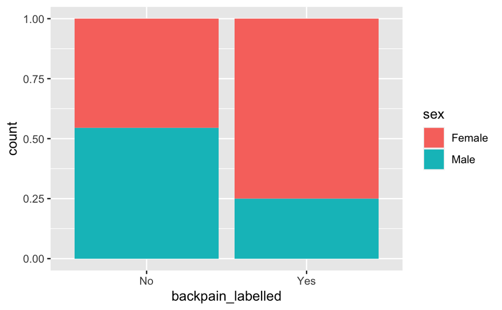

```r
backpack %>%
  ggplot(aes(x = backpain_labelled, fill = sex)) +
  geom_bar(position = "fill")
```

```r
NA
NA
```

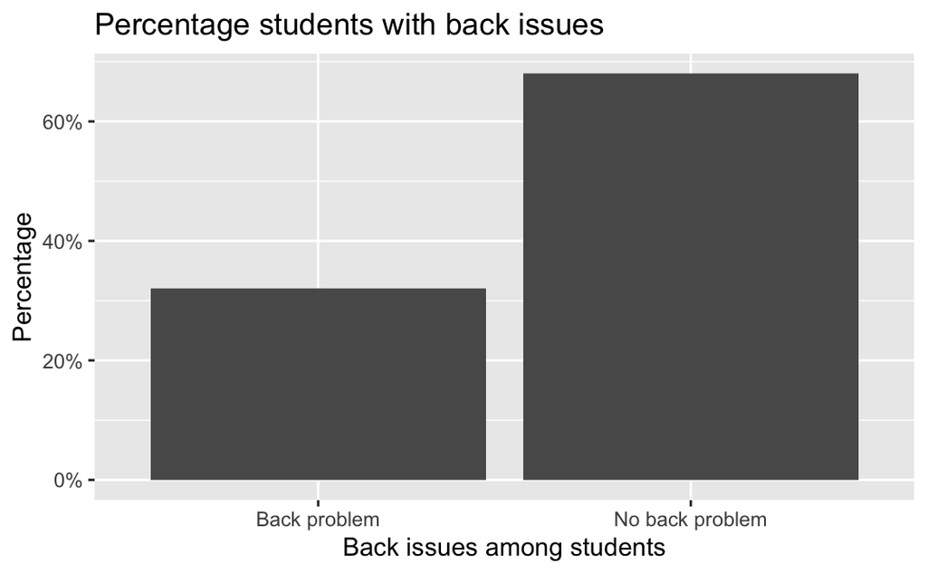

```r
backpack1 <- backpack %>%
  mutate(back_problems = recode(back_problems,
                               "1" = "Back problem",
                                "0" = "No back problem"))

backpack1 %>%
ggplot(aes(x = back_problems, y = after_stat(prop), group = 1)) +
  geom_bar() +
  xlab("Back issues among students") +
  ylab("Percentage") +
  ggtitle("Percentage students with back issues") +
  scale_y_continuous(labels = scales::percent_format())
```

[figure not shown]